# Title: Cooling benefits and forest structure similar across parks with varied land use histories

Authors: Isabella C. Richmond<sup>1</sup>*, Michael A. Paulauskas<sup>1</sup>, Erica Padvaiskas<sup>1</sup>, Laura Carolina Gonzalez Sinisterra<sup>2</sup>, Kayleigh Hutt-Taylor<sup>1</sup>, Alec L. Robitaille<sup>3</sup>, Carly D. Ziter<sup>1</sup>

1 Department of Biology, Concordia University, Montreal Canada, H4B 1R6  
2 Department of Biology, Universidad del Valle, Cali Columbia, 760042 3 Department of Biology, Memorial University of Newfoundland, St John’s Canada, A1C 5S7

* isabella.richmond@mail.concordia.ca, 438-439-8064

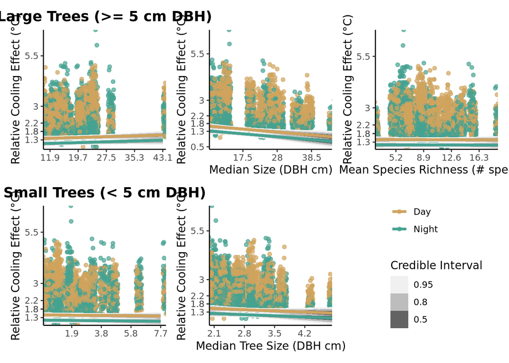

Figure S6. Visualization of the predicted relationships between forest composition and relative cooling effect, calculated while holding all other variables in the model constant and maintaining time of day as a random effect. Predicted draws were calculated 1,000 times, and then extracted and plotted. Coloured lines indicate mean predicted relationship, with grey credible intervals at 0.50, 0.8, and 0.95. Top 3 panels show the relationships between cooling and forest composition of large trees (trees with a diameter at breast height (DBH) of >= 5 cm). Bottom two panels show the relationships between cooling and forest composition of small trees (trees with DBH < 5 cm). Points represent raw data points, coloured by time of day.